# Práctica 3: Metaheurísticas basadas en poblaciones - Algoritmos Genéticos

## Instrucciones

Esto es **Jupyter Notebook**, un documento que integra código Python en un archivo Markdown. Esto nos permite ir ejecutando celdas de código poco a poco, así como generar automáticamente un informe bien formateado de la práctica.

Puedes añadir una celda con el botón **"Insert"** de la barra de herramentas, y cambiar su tipo con **"Cell > Cell Type"**

Para ejecutar una celda de código, la seleccionaremos y pulsaremos el botón **"▶ Run"** de la barra de herramentas. Para pasar el documento a HTML, seleccionaremos **"File > Download as > HTML (.html)"**

Sigue este guión hasta el final. Ejecuta el código proporcionado paso a paso comprendiendo lo que estás haciendo y reflexionando sobre los resultados. Habrá preguntas intercaladas a lo largo del guión, responde a todas ellas en la sección reservada para ese fin: **"Respuestas a los cuestionarios"**. Por favor, no modifiques ninguna linea de código excepto cuando se te pida explícitamente.

No olvides insertar tu **nombre y apellidos** en la celda superior.

IMPORTANTE: Escribe el código de tu o tus soluciones/respuestas en las celdas que se indican para ello. Además, a lo largo de la práctica se plantearán varias preguntas que debéis responder en la parte inferior del documento, incluyendo las celdas que veáis necesarias (si hacéis referencia a partes concretas de vuestro código, etc) para reponder a ellas.

## Entrega de la práctica

La fecha límite de entrega será la indicada en el Campus Virtual. La entrega consistirá de un único archivo comprimido con nombre `APELIDOS_NOME_Geneticos.zip` que contenga los seguientes ficheros:

- `APELIDOS_NOME_Geneticos.html`: Archivo HTML fruto de la exportación del presente Notebook, con las preguntas respondidas al final del documento.
- `APELIDOS_NOME_Geneticos.ipynb`: Archivo fuente Jupyter Notebook.
- Archivo de datos de los problema utilizados en la resolución.

## Preliminares adicionales sobre Python

Para esta práctica, te sugerimos algunas funciones de paquetes que pueden resultarte útiles en la realización de esta práctica.

Has visto que cuando realizas laboratorios y pruebas para ajustar parámetros resulta necesario tener una estimación del tiempo invertido en la ejecución. Eso ayuda a valorar el balance del tiempo computacional frente a la inclusión de valores de parámetros en el laboratorio. En ese sentido, puede resultar conveniente añadir barras de progreso que además te permitan visualizar el progreso de resolución de las iteraciones. Para ese propósito podéis hacer uso del paquete `tqdm` (https://tqdm.github.io/).

Puedes ver ejemplos en detalle descritos en https://towardsdatascience.com/progress-bars-for-python-with-tqdm-4dba0d4cb4c

Veámos un ejemplo ilustrativo aquí.

```python
# solo debes importarlo una vez en el notebook.
# fíjate que estamos importando del paquete tqdm.notebook para que incorpore los decoradores compatibles en Jupyter
# (en Python podrías importar simplemente desde el paquete tdqm)
from tqdm.notebook import trange, tqdm
```

`tqdm` permite añadir una barra de progreso que informe sobre el tiempo y el paso de iteraciones. En el ejemplo, la variable `nit` son el número de iteraciones a realizar y para conseguir que se visualize el progreso se pasa a `tqdm` un iterador de rango.

```python
from random import randint

heads = 0
tails = 0
nit=1000000
for i in tqdm(range(nit), desc='Coin Flip Progress'):
    toss = randint(0, 1)
    if toss == 0:
        heads += 1
    else:
        tails += 1
```

El paquete nos ofrece la posibilidad combinar `tdqm(range(NUM_IT))` en una única función, llamada `trange(NUM_IT)`. Veamos su funcionamiento en el siguiente ejemplo, que muestra también cómo podemos hacer cuando necesitamos llevar cuenta del progreso en bucles anidados.

```python
num_games = 3

for game in trange(num_games, desc='Overall Progress'):
    heads = 0
    tails = 0
    nit=1000000
    for j in trange((nit), desc=f'Game {game+1} Progress'):
        toss = randint(0, 1)
        if toss == 0:
            heads += 1
        else:
            tails += 1

    print(f'Heads: {heads}, Tails: {tails}')
```

```
Heads: 500421, Tails: 499579
```

```
Heads: 499309, Tails: 500691
```

```
Heads: 499722, Tails: 500278
```

Aprovechamos para recordarte que puedes utilizar semillas en la generación de secuencias de números aleatorios para hacer determinista y más verificable tu implementación.

```python
import random
import time
```

```python
# este vector será aleatorio si no habíamos establecido una semilla previamente.
# Podríamos tener incluso una semilla basada en el tiempo actual para forzar que se aleatorice
# si ejecutamos esta celda múltiples veces
random.seed(time.time())

vector_aleatorio = [ random.randint(1, 10) for i in range(1,10) ]
print ("vector aleatorio ", vector_aleatorio)

# aquí establecemos una semilla totalmente fija
# que no depende del tiempo y por tanto está bajo nuestro control
semilla = 123456
random.seed (semilla)

# este viene determinado por la semilla
vector_aleatorio = [ random.randint(1, 10) for i in range(1,10) ]
print ("vector aleatorio ", vector_aleatorio)

# y ahora somos capaces de generar la misma serie "aleatoria"
random.seed (semilla)
vector_aleatorio = [ random.randint(1, 10) for i in range(1,10) ]
print ("vector aleatorio igual que el anterior", vector_aleatorio)
```

```
vector aleatorio  [9, 2, 7, 5, 7, 4, 8, 4, 9]
vector aleatorio  [5, 1, 3, 1, 2, 1, 5, 1, 2]
vector aleatorio igual que el anterior [5, 1, 3, 1, 2, 1, 5, 1, 2]
```

Esto puede ser útil para verificar que siempre obtienes los mismos resultados ante el mismo conjunto de entradas.

## El Problema del Viajante de Comercio (VC) con Algoritmos Genéticos

El objetivo de esta práctica es modelar e implementar un agente inteligente que sea capaz de resolver el problema del VC mediante la metaheurística (MH) de poblaciones conocida como Algoritmo Genético (GA, del inglés *Genetic Algorithm*). Para ello, realizarás una implementación del algoritmo básico visto en la clase expositiva y valorarás si la introducción de modificaciones en el diseño del algoritmo te permite mejorar la calidad de las soluciones alcanzadas.

### Definición del problema de Viajante de Comercio (VC)

La definición del problema sigue la descripción ya vista en las prácticas anterior, en la que se disponía de una represetación del problema mediante un grafo ponderado. Así que, en primer lugar importa el módulo Python que acompaña esta práctica, que ya trae las funciones de apoyo como la clase `Localizaciones` que implementaba la carga de datos y que utilizaba una matriz de adyacencia.

```python
from helpers_mod_ga import *
```

Si todo va bien, la primera distancia entre la ciudad 0 y 1 debe ser unos 55 km para el problema de las 8 ciudades gallegas.

```python
g1=Localizaciones(filename='./data/grafo8cidades.txt')
print (g1.distancia(0,1))
```

```
55.88273580792048
```

## P3.1: Implementación básica de Algoritmo Genético

Implementa un algoritmo genético básico para resolver el problema del VC, siguiendo la descripción algorítmica de la MH vista en la clase expositiva.

Ten en cuenta las siguientes consideraciones de diseño para completar esta implementación básica:

- Representación de las soluciones: representación de orden (permutaciones) comenzando y finalizando en la ciudad 0.
- Población inicial: inicialización completamente aleatoria de la población inicial, que sean permutaciones válidas.
- Operador de cruce: Order Crossover (OX). La función/método que se encargue de hacer el cruce ordenado debe aceptar como parámetros la probabilidad de cruce (por defecto, establecida a pc=0.95), los dos puntos de corte así como los cromosomas sobre los que actuar.
- Operador de mutación: se utilizará el operador de intercambio, aplicado con una probabilidad de mutación. Vuestra implementación debe manejar dos variantes de esta función:
  - Mutación individual: solo se aplica la mutación, si procede, sobre un único gen en el cromosoma. La probabilidad de mutación por defecto se establece pm=0.25. Esta función debería recibir el índice del gen sobre el que actuar además de la probabilidad de mutación y el cromosoma original.
  - Mutación cromosómica: se aplica la mutación contemplando todo el cromosoma, de forma que individualmente puede mutar cada gen de manera independiente según una probabilidad de mutación, establecida por defecto a pm=0.01.
- El reemplazo de la generación debe seguir un modelo de reemplazo generacional con elitismo. En particular, tu implementación debe disponer de dos variantes de la función de reemplazo:
  - mitades: haz que la mitad de la población resultante del reemplazo provenga de la generación actual mientras que la otra mitad provenga de los descendientes, tomando en ambos casos los mejores individuos.
  - elitismo "elite=2": de esta forma, hay que mantener los 2 mejores individuos de la generación actual/ancestros; mientras que el resto provienen de entre los mejores hijos. La función de reemplazo debería parametrizar "elite".

Ambas variantes deben recibir como parámetro la lista de cromosomas de las poblaciones ascentros e hijos generados y retornar la población resultante.

- Condición de parada simple basado en un número de iteraciones máximo pasado como parámetro.
- La implementación debe ser completamente parametrizable, de forma que todos los componentes susceptibles de ser ajustados mediante parámetros deberían puedan ser establecidos en cada ejecución/problema.

Lanza varias ejecuciones para verificar que puede resolver el problema con los siguientes grafos de ejemplo:

- grafo 8 ciudades gallegas (`data/grafo8cidades.txt`), con una población de 2 individuos y 150 iteraciones.
- grafo 120 ciudades estadounidenses (`data/US120.txt`), con una población de 32 individuos y 500 iteraciones.

Si no te convergiera, prueba a extender el número de iteraciones o variar parámetros como la probabilidad de mutación.

```python
def cost(Loc, solution):
    cost=0
    aux = [0] + solution + [0]
    for i in range(0,len(aux)-1):
        cost+= Loc.distancia(aux[i], aux[i+1])
    return cost;

def cost_population(Loc, population):
    cost_population=[(solution, cost(Loc, solution)) for solution in population]
    return sorted(cost_population, key=lambda cost_population: cost_population[1])
```

```python
def gen_initial_solution(Loc):
    initial_solution = list(range(1, Loc.nciudades))
    random.shuffle(initial_solution)
    return initial_solution

def generate_initial_population(Loc, n):
    population = []
    for i in range(n):
        solution = gen_initial_solution(Loc)
        population.append(solution)
    return population

def copy_population(population):
    copied_population = []
    for solution in population:
        copied_solution = solution.copy()
        copied_population.append(copied_solution)
    return copied_population
```

```python
from itertools import permutations
def group_in_pairs(population):

    n = len(population)
    indices = list(range(n))
    pairs = []
    for perm in permutations(indices, 2):
        i, j = perm
        if i < j:
           pairs.append((population[i], population[j]))

    return pairs
```

```python
def order_crossover_aux(pair, probability_order_crossover):
    probability = random.uniform(0,1)
    if probability >= probability_order_crossover:
        return pair

    crossover_point_0 = random.randint(0, len(pair[0])-2)
    crossover_point_1 = random.randint(crossover_point_0+1, len(pair[0])-1)

    pair_aux_0 = [None] * len(pair[0])
    pair_aux_1 = [None] * len(pair[0])

    cambios_0 = []
    cambios_1 = []

    for i in range(0,len(pair[0])):
        if(i >= crossover_point_0 and i <= crossover_point_1):
            pair_aux_0[i]= pair[1][i]
            cambios_1.append(pair[1][i])
            pair_aux_1[i] = pair[0][i]
            cambios_0.append(pair[0][i])
            continue

        pair_aux_0[i]= pair[0][i]
        pair_aux_1[i] = pair[1][i]

    cambios_0_aux = []
    cambios_1_aux = []
    for i in range(0,len(cambios_0)):
        if cambios_0[i] not in cambios_1:
            cambios_0_aux.append(cambios_0[i])
        if cambios_1[i] not in cambios_0:
            cambios_1_aux.append(cambios_1[i])

    i0 = 0
    i1 = 0
    for i in range(0,len(pair[0])):
        if(i0 == len(cambios_0_aux) and i1 == i0):
            break
        if(i >= crossover_point_0 and i <= crossover_point_1):
            continue
        if pair_aux_0[i] in cambios_1_aux:
            pair_aux_0[i] = cambios_0_aux[i0]
            i0+=1
        if pair_aux_1[i] in cambios_0_aux:
            pair_aux_1[i] = cambios_1_aux[i1]
            i1+=1
    return (pair_aux_0, pair_aux_1);
```

```python
def order_crossover(pair, probability_order_crossover):
    probability = random.uniform(0,1)
    if probability >= probability_order_crossover:
        return pair

    crossover_point_0 = random.randint(0, len(pair[0])-2)
    crossover_point_1 = random.randint(crossover_point_0+1, len(pair[0])-1)

    pair_aux_0 = [None] * len(pair[0])
    pair_aux_1 = [None] * len(pair[0])

    for i in range(crossover_point_0,crossover_point_1 + 1):
        pair_aux_0[i]= pair[1][i]
        pair_aux_1[i] = pair[0][i]

    ##Primer hijo
    pair_position, aux_position = crossover_point_1 + 1, crossover_point_1 + 1
    if pair_position > len(pair[1]) - 1:
        pair_position = 0
    aux_position = pair_position

    for i in range(len(pair[0])):
        if pair_aux_0[aux_position] is None:
            while pair[0][pair_position] in pair_aux_0:
                pair_position = (pair_position + 1) % len(pair[0])

            pair_aux_0[aux_position] = pair[0][pair_position]
            pair_position = (pair_position + 1) % len(pair[0])

        aux_position = (aux_position + 1) % len(pair[0])

    ##Segundo hijo
    pair_position, aux_position = crossover_point_1 + 1, crossover_point_1 + 1
    if pair_position > len(pair[1]) - 1:
        pair_position = 0
    aux_position = pair_position

    for i in range(len(pair[1])):
        if pair_aux_1[aux_position] is None:
            while pair[1][pair_position] in pair_aux_1:
                pair_position = (pair_position + 1) % len(pair[1])

            pair_aux_1[aux_position] = pair[1][pair_position]
            pair_position = (pair_position + 1) % len(pair[1])

        aux_position = (aux_position + 1) % len(pair[1])


    return (pair_aux_0, pair_aux_1);
```

```python
def individual_mutation(solution, probability_mutation):
    probability = random.uniform(0,1)

    if probability <= probability_mutation:
        i0 = random.randint(0, len(solution)-2)
        i1 = random.randint(i0+1, len(solution)-1)
        solution[i0], solution[i1] = solution[i1], solution[i0]
        return solution

    return solution;

def chromosomal_mutation(solution, probability_mutation):
    for i in range(len(solution)):
        probability = random.uniform(0,1)

        if probability <= probability_mutation:
            i0 = random.randint(0, len(solution)-1)
            solution[i], solution[i0] = solution[i0], solution[i]

    return solution;
```

```python
def mitades(Loc, parents, children):
    parents_fitness = cost_population(Loc, parents)
    children_fitness = cost_population(Loc, children)
    new_population = []
    for i in range(int(len(parents_fitness) / 2)):
        new_population.append(parents_fitness[i][0])
        new_population.append(children_fitness[i][0])

    return new_population

def elite(Loc, parents, children):
    parents_fitness = cost_population(Loc, parents)
    children_fitness = cost_population(Loc, children)
    new_population = []
    n = 2
    for i in range(n):
        new_population.append(parents_fitness[i][0])

    for i in range(len(parents_fitness)-n):
        new_population.append(parents_fitness[i][0])

    return new_population
```

```python
import copy
import random
import time

def genetic_algorithm(Loc, number_population, iterations, probability_mutation, probability_order_crossover, mutation, new_population):
    population = generate_initial_population(Loc, number_population)
    better_solutions = []
    k = 0
    while (k != iterations):
        parents = copy_population(population)

        children = []
        for pair in group_in_pairs(population):
            pair = order_crossover(pair, probability_order_crossover)
            for solution in pair:
                solution = mutation(solution, probability_mutation)
                children.append(solution)


        k+=1
        population = new_population(Loc, parents, children)
        #better_solutions.append(cost_population(Loc, population)[0])

    return cost_population(Loc, population)[0]
```

```python
def mitades_individual(Loc, n, it,  probability_mutation, probability_order_crossover):
    return genetic_algorithm(Loc, n, it,  probability_mutation, probability_order_crossover, individual_mutation, mitades)
```

```python
mitades_individual(Localizaciones(filename='./data/grafo8cidades.txt'), 2, 150, 0.25, 0.95)
```

```
([7, 6, 5, 4, 3, 2, 1], 381.6699617675482)
```

```python
mitades_individual(Localizaciones(filename='./data/US120.txt'), 32, 500, 0.25, 0.95)
```

```
([88,
  96,
  103,
  17,
  25,
  70,
  73,
  31,
  112,
  87,
  72,
  54,
  61,
  1,
  115,
  106,
  116,
  29,
  39,
  76,
  102,
  44,
  30,
  45,
  6,
  57,
  97,
  48,
  46,
  104,
  85,
  33,
  108,
  95,
  5,
  118,
  15,
  67,
  12,
  19,
```

[output cut: 65 more lines]

```
  16,
  59,
  4,
  105,
  40,
  38,
  8,
  119,
  81,
  51,
  79,
  101,
  77,
  78],
 30651.119254810255)
```

```python
def mitades_cromosomica(Loc, n, it,  probability_mutation, probability_order_crossover):
    return genetic_algorithm(Loc, n, it,  probability_mutation, probability_order_crossover, chromosomal_mutation, mitades)
```

```python
mitades_cromosomica(Localizaciones(filename='./data/grafo8cidades.txt'), 2, 150, 0.1, 0.95)
```

```
([5, 4, 3, 2, 1, 7, 6], 466.2946852391607)
```

```python
mitades_cromosomica(Localizaciones(filename='./data/US120.txt'), 32, 500, 0.1, 0.95)
```

```
([25,
  39,
  85,
  112,
  57,
  97,
  93,
  72,
  95,
  49,
  33,
  108,
  116,
  30,
  44,
  45,
  6,
  76,
  48,
  104,
  46,
  82,
  59,
  94,
  65,
  28,
  99,
  71,
  42,
  96,
  60,
  36,
  4,
  52,
  23,
  87,
  3,
  21,
  41,
  24,
```

[output cut: 65 more lines]

```
  90,
  100,
  58,
  75,
  63,
  43,
  81,
  119,
  10,
  84,
  89,
  13,
  83,
  107],
 102744.28745488836)
```

```python
def elite_individual(Loc, n, it,  probability_mutation, probability_order_crossover):
    return genetic_algorithm(Loc, n, it,  probability_mutation, probability_order_crossover, individual_mutation, elite)
```

```python
elite_individual(Localizaciones(filename='./data/grafo8cidades.txt'), 2, 150, 0.25, 0.95)
```

```
([2, 5, 3, 1, 4, 6, 7], 645.1673968659666)
```

```python
elite_individual(Localizaciones(filename='./data/US120.txt'), 32, 500, 0.25, 0.95)
```

```
([106,
  108,
  55,
  59,
  116,
  96,
  25,
  85,
  31,
  77,
  36,
  107,
  119,
  79,
  101,
  56,
  48,
  65,
  94,
  9,
  10,
  112,
  13,
  16,
  19,
  28,
  83,
  98,
  1,
  29,
  104,
  102,
  114,
  88,
  37,
  103,
  21,
  73,
  74,
  41,
```

[output cut: 65 more lines]

```
  71,
  50,
  68,
  97,
  44,
  30,
  78,
  3,
  38,
  12,
  110,
  61,
  49,
  34],
 173439.22050446243)
```

```python
def elite_cromosomica(Loc, n, it,  probability_mutation, probability_order_crossover):
    return genetic_algorithm(Loc, n, it,  probability_mutation, probability_order_crossover, chromosomal_mutation, elite)
```

```python
elite_cromosomica(Localizaciones(filename='./data/grafo8cidades.txt'), 2, 150, 0.1, 0.95)
```

```
([7, 4, 6, 5, 1, 3, 2], 637.1349724861498)
```

```python
elite_cromosomica(Localizaciones(filename='./data/US120.txt'), 32, 500, 0.1, 0.95)
```

```
([91,
  68,
  44,
  102,
  19,
  86,
  74,
  71,
  72,
  32,
  62,
  110,
  95,
  53,
  36,
  119,
  105,
  115,
  78,
  83,
  23,
  35,
  59,
  55,
  94,
  18,
  4,
  112,
  37,
  48,
  54,
  87,
  27,
  92,
  116,
  93,
  96,
  41,
  114,
  90,
```

[output cut: 65 more lines]

```
  108,
  20,
  13,
  100,
  3,
  2,
  10,
  38,
  84,
  57,
  64,
  98,
  99,
  107],
 171191.51722782012)
```

❓ **Pregunta 1**. Explica brevemente los detalles relevantes de tu código para entender tu implementación (p.ej., estructura de tu código, funciones, implementación de operadores, etc.). ¿Cuál es el mecanismo de selección escogido para tu implementación? Explica también cómo has verificado tu implementación.

## P3.2: Laboratorio

Como toda metaheurística, resulta crucial conocer cómo afecta en términos prácticos los parámetros del algoritmo y los operadores desarrollados. Estudia el comportamiento del algoritmo implementado para resolver VC atendiendo a las siguientes cuestiones.

❓ **Pregunta 2**. Realiza el estudio de la calidad de la solución variando el tamaño de la población: 1, 2, 4, 8, 16, 32, 64... ¿Qué valor recomendarías para el problema de las 120 ciudades? ¿Por qué? Ten en cuenta que tienes dos variantes del mecanismo de reemplazo.

❓ **Pregunta 3**. Ahora realiza un estudio similar variando la probabilidad de mutación en el rango 0, ..., 0.95 en pasos de 0.05~0.10. ¿Qué valor recomendarías para este parámetro? ¿Por qué? Ten en cuenta que tienes dos variantes del mecanismo de mutación.

❓ **Pregunta 4**. Finalmente realiza un estudio variando el número de iteraciones máximas en el rango de 50 a 1000, considerando un paso variable o adaptativo a conveniencia. ¿Qué valor recomendarías para este parámetro? ¿Por qué? Realiza una discusión reflexionando sobre los resultados conjuntos de estos tres parámetros.

Apoya todas tus respuestas en datos-gráficos resultantes de tus estudios, reportados de forma que sea fácil de comparar/contrastar.

Importante: además de la calidad de la soluciones obtenidas, se recomienda medir tiempos para tomar medidas operativas sobre el número de repeticiones que permitan realizar promedios (se recomienda no más de 10 si se ralentiza mucho) y prescindir de manera razonada de valores en las series de ejecución que no sean computacionalmente rentables/viables con tu implementación/ordenador (p.ej., tamaños de población elevados pueden tomar mucho tiempo para resolver).

#### Respuestas y evaluación

Recordatorio: No olvides escribir tu nombre y apellidos en la segunda celda de este documento. La respuestas a las preguntas deben venir acompañadas de las implementaciones necesarias para su respuesta.

*P3.1: Implementación básica* (5 puntos)

La implementación básica se evaluará mediante un cuestionario automático de evaluación. Este lo realizarás en la primera sesión tras la entrega, y se centrará en la resolución por tu parte de diversas cuestiones prácticas relacionadas con la implementación realizada, pudiendo ser necesaria la ejecución, adaptación y modificación de la misma.

Pregunta 1.

Independientemente del cuestionario automático de evaluación, considera siempre que las preguntas planteadas en el notebook deben ser respondidas también. Esas preguntas generales están diseñadas para formarte, y te servián para razonar y reflexionar sobre el tema, así como también para fomentar una discusión constructiva con los docentes en caso de dudas.

**P3.2: Laboratorio** (5 puntos)

Pregunta 2.

Pregunta 3.

Pregunta 4.

El informe a elaborar no debe exceder la longitud máxima de 1200 palabras.

Aclaraciones: La evaluación de esta parte se llevará a cabo en términos de la completitud y correctitud del laboratorio implementado, así como de la calidad del propio informe, que debe ser conciso y preciso, pudiendo acompañarse de gráficas y tablas que faciliten y fundamenten la explicación e argumentación. Es muy importante explicar de manera clara, precisa y fundamentada. Se reservará hasta un punto que se asignará en términos de la calidad de la mejor solución obtenida entre el conjunto de las prácticas entregadas (es por ello que no debes olvidar marcar en tu informe muy claramente cuál ha sido tu mejor solución y con qué configuración/versión).

# Implemetación Básica

```python
def cost(Loc, solution):
    cost=0
    aux = [0] + solution + [0]
    for i in range(0,len(aux)-1):
        cost+= Loc.distancia(aux[i], aux[i+1])
    return cost;

def cost_population(Loc, population):
    cost_population=[(solution, cost(Loc, solution)) for solution in population]
    return sorted(cost_population, key=lambda cost_population: cost_population[1])
```

```python
def gen_initial_solution(Loc):
    initial_solution = list(range(1, Loc.nciudades))
    random.shuffle(initial_solution)
    return initial_solution

def generate_initial_population(Loc, n):
    population = []
    for i in range(n):
        solution = gen_initial_solution(Loc)
        population.append(solution)
    return population

def copy_population(population):
    copied_population = []
    for solution in population:
        copied_solution = solution.copy()
        copied_population.append(copied_solution)
    return copied_population
```

```python
from itertools import permutations
def group_in_pairs(population):

    n = len(population)
    indices = list(range(n))
    pairs = []
    for perm in permutations(indices, 2):
        i, j = perm
        if i < j:
           pairs.append((population[i], population[j]))

    return pairs
```

```python
def order_crossover(pair, probability_order_crossover):
    probability = random.uniform(0,1)
    if probability >= probability_order_crossover:
        return pair

    crossover_point_0 = random.randint(0, len(pair[0])-2)
    crossover_point_1 = random.randint(crossover_point_0+1, len(pair[0])-1)

    pair_aux_0 = [None] * len(pair[0])
    pair_aux_1 = [None] * len(pair[0])

    for i in range(crossover_point_0,crossover_point_1 + 1):
        pair_aux_0[i]= pair[1][i]
        pair_aux_1[i] = pair[0][i]

    ##Primer hijo
    pair_position, aux_position = crossover_point_1 + 1, crossover_point_1 + 1
    if pair_position > len(pair[1]) - 1:
        pair_position = 0
    aux_position = pair_position

    for i in range(len(pair[0])):
        if pair_aux_0[aux_position] is None:
            while pair[0][pair_position] in pair_aux_0:
                pair_position = (pair_position + 1) % len(pair[0])

            pair_aux_0[aux_position] = pair[0][pair_position]
            pair_position = (pair_position + 1) % len(pair[0])

        aux_position = (aux_position + 1) % len(pair[0])

    ##Segundo hijo
    pair_position, aux_position = crossover_point_1 + 1, crossover_point_1 + 1
    if pair_position > len(pair[1]) - 1:
        pair_position = 0
    aux_position = pair_position

    for i in range(len(pair[1])):
        if pair_aux_1[aux_position] is None:
            while pair[1][pair_position] in pair_aux_1:
                pair_position = (pair_position + 1) % len(pair[1])

            pair_aux_1[aux_position] = pair[1][pair_position]
            pair_position = (pair_position + 1) % len(pair[1])

        aux_position = (aux_position + 1) % len(pair[1])


    return (pair_aux_0, pair_aux_1);
```

```python
def individual_mutation(solution, probability_mutation):
    probability = random.uniform(0,1)

    if probability <= probability_mutation:
        i0 = random.randint(0, len(solution)-2)
        i1 = random.randint(i0+1, len(solution)-1)
        solution[i0], solution[i1] = solution[i1], solution[i0]
        return solution

    return solution;

def chromosomal_mutation(solution, probability_mutation):
    for i in range(len(solution)):
        probability = random.uniform(0,1)

        if probability <= probability_mutation:
            i0 = random.randint(0, len(solution)-1)
            solution[i], solution[i0] = solution[i0], solution[i]

    return solution;
```

```python
def mitades(Loc, parents, children):
    parents_fitness = cost_population(Loc, parents)
    children_fitness = cost_population(Loc, children)
    new_population = []
    for i in range(int(len(parents_fitness) / 2)):
        new_population.append(parents_fitness[i][0])
        new_population.append(children_fitness[i][0])

    return new_population

def elite(Loc, parents, children):
    parents_fitness = cost_population(Loc, parents)
    children_fitness = cost_population(Loc, children)
    new_population = []
    n = 2
    for i in range(n):
        new_population.append(parents_fitness[i][0])

    for i in range(len(parents_fitness)-n):
        new_population.append(parents_fitness[i][0])

    return new_population
```

```python
import copy
import random
import time

def genetic_algorithm(Loc, number_population, iterations, probability_mutation, probability_order_crossover, mutation, new_population):
    population = generate_initial_population(Loc, number_population)
    k = 0
    while (k != iterations):
        parents = copy_population(population)

        children = []
        for pair in group_in_pairs(population):
            pair = order_crossover(pair, probability_order_crossover)
            for solution in pair:
                solution = mutation(solution, probability_mutation)
                children.append(solution)


        k+=1
        population = new_population(Loc, parents, children)

    return cost_population(Loc, population)[0]
```

```python
def mitades_individual(Loc, n, it,  probability_mutation, probability_order_crossover):
    return genetic_algorithm(Loc, n, it,  probability_mutation, probability_order_crossover, individual_mutation, mitades)
```

```python
mitades_individual(Localizaciones(filename='./data/grafo8cidades.txt'), 2, 150, 0.25, 0.95)
```

```
([1, 2, 3, 4, 5, 6, 7], 381.6699617675482)
```

```python
def mitades_cromosomica(Loc, n, it,  probability_mutation, probability_order_crossover):
    return genetic_algorithm(Loc, n, it,  probability_mutation, probability_order_crossover, chromosomal_mutation, mitades)
```

```python
mitades_cromosomica(Localizaciones(filename='./data/grafo8cidades.txt'), 2, 150, 0.1, 0.95)
```

```
([1, 2, 3, 4, 5, 6, 7], 381.6699617675482)
```

```python
def elite_individual(Loc, n, it,  probability_mutation, probability_order_crossover):
    return genetic_algorithm(Loc, n, it,  probability_mutation, probability_order_crossover, individual_mutation, elite)
```

```python
elite_individual(Localizaciones(filename='./data/grafo8cidades.txt'), 2, 150, 0.25, 0.95)
```

```
([7, 5, 4, 3, 6, 2, 1], 593.251566697314)
```

```python
def elite_cromosomica(Loc, n, it,  probability_mutation, probability_order_crossover):
    return genetic_algorithm(Loc, n, it,  probability_mutation, probability_order_crossover, chromosomal_mutation, elite)
```

```python
elite_cromosomica(Localizaciones(filename='./data/grafo8cidades.txt'), 2, 150, 0.1, 0.95)
```

```
([5, 6, 7, 1, 4, 3, 2], 573.1803694820359)
```

```python
import statistics
from tqdm.notebook import trange, tqdm
def pruebas(nombre_prueba, algoritmo, Loc, n, it,  probability_mutation, probability_order_crossover):
    tiempos = []
    resultados = []
    print(nombre_prueba)
    for i in tqdm(range(5), desc=nombre_prueba):
        inicio = time.time()
        a = algoritmo(Loc, n, it,  probability_mutation, probability_order_crossover)
        delta_time = time.time() - inicio
        tiempos.append(delta_time)
        resultados.append(a[1])

    mediaT = statistics.mean(tiempos)
    print("La media de los tiempos es: ", mediaT)
    desvtipT = statistics.stdev(tiempos)
    print("La desviacion de los tiempos es: ", desvtipT)

    mediaR = statistics.mean(resultados)
    print("La media de los resultados es: ", mediaR)
    desvtipR = statistics.stdev(resultados)
    print("La desviacion de los resultados es: ", desvtipR)
    print("-------------\n")

    return (resultados, tiempos, mediaR, mediaT)
```

```python
import matplotlib.pyplot as plt
import numpy as np

def graficar(resultados, tiempos, mediasR, mediasT, test):
    # Crear una figura y una matriz de subgráficas con 1 fila y 2 columnas
    fig, axs = plt.subplots(1, 2, figsize=(5, 2))

    # Grafica 1
    axs[0].set_title("Coste - TamPoblacion")
    axs[0].set_xticks(test)

    for pob in tqdm(test, leave=None):
        axs[0].plot(test, resultados, "bo")

    # Grafica 2
    axs[1].set_title("Tiempo - TamPoblacion")
    axs[1].set_xticks(test)

    for pob in tqdm(test, leave=None):
        axs[1].plot(test, tiempos, "bo")

    # Crear una línea que una las medias de a2 y a3
    axs[0].plot(test, mediasR, 'r-', label='Media Resultados')
    axs[1].plot(test, mediasT, 'r-', label='Media Tiempo')

    # Ajusta el diseño para evitar solapamientos
    plt.tight_layout()

    # Muestra las gráficas
    plt.show()
```

# Informe de Laboratorio

En este laboratorio se va a analizar la implementación desarrollada para el problema del Viajante Comercio, a través de algoritmos genéticos. Para esta implementación existen distintas variantes en la forma de mutar los cromosomas y a la hora de seleccionar los mejores hijos. En cuanto a la selección de padres, se realiza utilizando el mecanismo de agrupación por pares o lo que es equivalente a todas las permutaciones, de tamaño dos, sobre la población. No se permiten permutaciones donde el primer indice es mayor que el segundo, para evitar agrupaciones repetidas, ni se permiten agrupaciones consigo mismo.

Las distintas variantes estas compuestas por la forma de seleccionar a los hijos (mitades o elitimos) y por la forma en la que se pueden generar mutaciones(individual o cromosomica):

**Mitades individual:** En esta variante se seleccinan la mitad de los mejores hijos y la mitad de los mejores padres para generar la nueva población. Además, se realiza mutación individual sobre un único gen del cromosoma.

**Mitades cromosómica:** En esta variante se seleccinan la mitad de los mejores hijos y la mitad de los mejores padres para generar la nueva población. Además, se realiza mutación cromosómica sobre todo el cromosoma.

Para realizar el estudio se ha tomado la implementación básica y se han construido distintas funciones que facilan la elaboración de las pruebas:

```
import statistics
from tqdm.notebook import trange, tqdm
def pruebas(nombre_prueba, algoritmo, Loc, n, it,  probability_mutation, probability_order_crossover):
    tiempos = []
    resultados = []
    print(nombre_prueba)
    for i in tqdm(range(5), desc=nombre_prueba):
        inicio = time.time()
        a = algoritmo(Loc, n, it,  probability_mutation, probability_order_crossover)
        delta_time = time.time() - inicio
        tiempos.append(delta_time)
        resultados.append(a[1])

    mediaT = statistics.mean(tiempos)
    print("La media de los tiempos es: ", mediaT)
    desvtipT = statistics.stdev(tiempos)
    print("La desviacion de los tiempos es: ", desvtipT)

    mediaR = statistics.mean(resultados)
    print("La media de los resultados es: ", mediaR)
    desvtipR = statistics.stdev(resultados)
    print("La desviacion de los resultados es: ", desvtipR)
    print("-------------\n")

    return (resultados, tiempos, mediaR, mediaT)
```

Por ejemplo, para estudiar el tamaño de la población:

```
test = [2, 4, 8, 16, 32, 64]
a0 = []
a1 = []
a2 = []
a3 = []
for i in tqdm(test, desc="Mitades Individual"):
    per = pruebas("Mitades Individual con n=" + str(i), mitades_individual, Localizaciones(filename='./data/US120.txt'), i, 500, 0.25, 0.95)
    a0.append(per[0])
    a1.append(per[1])
    a2.append(per[2])
    a3.append(per[3])
```

Una vez se ejecutan las diferentes pruebas, sobre las distintas variantes, se debe analizar la información obtenida y siempre es más fácil hacerlo a través de graficas:

```
import matplotlib.pyplot as plt
import numpy as np

def graficar(resultados, tiempos, mediasR, mediasT, test):
    # Crear una figura y una matriz de subgráficas con 1 fila y 2 columnas
    fig, axs = plt.subplots(1, 2, figsize=(5, 2))

    # Grafica 1
    axs[0].set_title("Coste")
    axs[0].set_xticks(test)

    for pob in tqdm(test, leave=None):
        axs[0].plot(test, resultados, "bo")

    # Grafica 2
    axs[1].set_title("Tiempo")
    axs[1].set_xticks(test)

    for pob in tqdm(test, leave=None):
        axs[1].plot(test, tiempos, "bo")

    # Crear una línea que una las medias de a2 y a3
    axs[0].plot(test, mediasR, 'r-', label='Media Resultados')
    axs[1].plot(test, mediasT, 'r-', label='Media Tiempo')

    # Ajusta el diseño para evitar solapamientos
    plt.tight_layout()

    # Muestra las gráficas
    plt.show()
```

De esta manera se estudiará y analizará la implemetación del algoritmo genético utilizado, en cuanto a su coste temporal y su coste en la solución óptima.

## Pregunta 2. Tamaño de la población

### Parte Experimental

```python
test = [2, 4, 8, 16, 32, 64]
a0 = []
a1 = []
a2 = []
a3 = []
for i in tqdm(test, desc="Mitades Individual"):
    per = pruebas("Mitades Individual con n=" + str(i), mitades_individual, Localizaciones(filename='./data/US120.txt'), i, 500, 0.25, 0.95)
    a0.append(per[0])
    a1.append(per[1])
    a2.append(per[2])
    a3.append(per[3])
```

```
Mitades Individual con n=2
```

```
La media de los tiempos es:  0.1244081974029541
La desviacion de los tiempos es:  0.005239909289305199
La media de los resultados es:  121808.55582556556
La desviacion de los resultados es:  3535.124446857979
-------------

Mitades Individual con n=4
```

```
La media de los tiempos es:  0.6578619480133057
La desviacion de los tiempos es:  0.015304046703935899
La media de los resultados es:  83723.72278810224
La desviacion de los resultados es:  4007.0006705820633
-------------

Mitades Individual con n=8
```

```
La media de los tiempos es:  2.9053447246551514
La desviacion de los tiempos es:  0.03947135269260479
La media de los resultados es:  60537.2851667546
La desviacion de los resultados es:  3741.0754404200284
-------------

Mitades Individual con n=16
```

```
La media de los tiempos es:  12.432420444488525
La desviacion de los tiempos es:  0.08087272070344412
La media de los resultados es:  45432.530423097254
La desviacion de los resultados es:  3255.365272497711
-------------

Mitades Individual con n=32
```

```
La media de los tiempos es:  51.561782884597775
La desviacion de los tiempos es:  0.26717960723301665
La media de los resultados es:  38096.542469058215
La desviacion de los resultados es:  2050.759233916611
-------------

Mitades Individual con n=64
```

```
La media de los tiempos es:  215.32630081176757
La desviacion de los tiempos es:  5.078585340864328
La media de los resultados es:  31300.89268437867
La desviacion de los resultados es:  2653.5794708539356
-------------
```

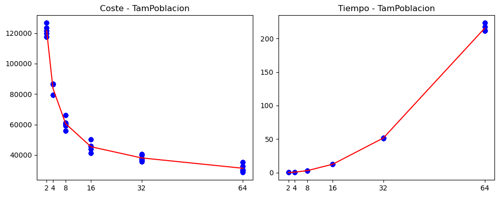

```python
graficar(a0,a1,a2,a3,test)
```

```python
test = [2, 4, 8, 16, 32, 64]
b0 = []
b1 = []
b2 = []
b3 = []
for i in tqdm(test, desc="Mitades Cromosomica"):
    per = pruebas("Mitades Cromosomica con n=" + str(i), mitades_cromosomica, Localizaciones(filename='./data/US120.txt'), i, 500, 0.1, 0.95)
    b0.append(per[0])
    b1.append(per[1])
    b2.append(per[2])
    b3.append(per[3])
```

```
Mitades Cromosomica con n=2
```

```
La media de los tiempos es:  0.1573857307434082
La desviacion de los tiempos es:  0.006112549656704527
La media de los resultados es:  137612.5755465555
La desviacion de los resultados es:  3220.3216656896075
-------------

Mitades Cromosomica con n=4
```

```
La media de los tiempos es:  0.853283166885376
La desviacion de los tiempos es:  0.009475786153102824
La media de los resultados es:  127117.90338366265
La desviacion de los resultados es:  5274.308000593617
-------------

Mitades Cromosomica con n=8
```

```
La media de los tiempos es:  4.047230577468872
La desviacion de los tiempos es:  0.11562610261261624
La media de los resultados es:  115807.39395139739
La desviacion de los resultados es:  6881.9121027935935
-------------

Mitades Cromosomica con n=16
```

```
La media de los tiempos es:  16.7472740650177
La desviacion de los tiempos es:  0.1635101512192728
La media de los resultados es:  107838.55073315193
La desviacion de los resultados es:  4689.066448904261
-------------

Mitades Cromosomica con n=32
```

```
La media de los tiempos es:  71.56442260742188
La desviacion de los tiempos es:  2.043016778379472
La media de los resultados es:  100756.62927726918
La desviacion de los resultados es:  3660.654629217753
-------------

Mitades Cromosomica con n=64
```

```
La media de los tiempos es:  286.3671824455261
La desviacion de los tiempos es:  8.37196156155623
La media de los resultados es:  101499.07972164953
La desviacion de los resultados es:  4975.523243625669
-------------
```

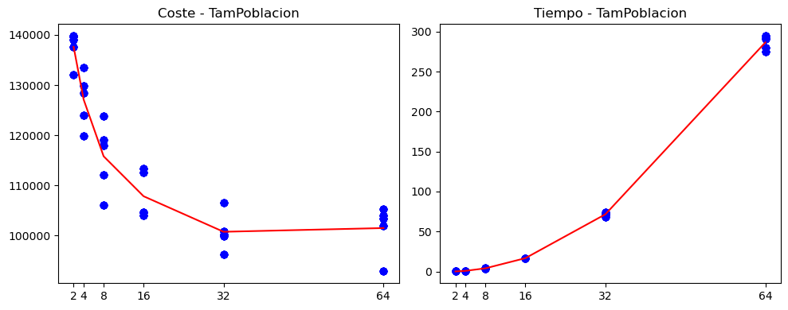

```python
graficar(b0,b1,b2,b3,test)
```

```python
test = [2, 4, 8, 16, 32, 64]
c0 = []
c1 = []
c2 = []
c3 = []
for i in tqdm(test, desc="Elite Individual"):
    per = pruebas("Elite Cromosomica con n=" + str(i), elite_individual, Localizaciones(filename='./data/US120.txt'), i, 500, 0.25, 0.95)
    c0.append(per[0])
    c1.append(per[1])
    c2.append(per[2])
    c3.append(per[3])
```

```
Elite Cromosomica con n=2
```

```
La media de los tiempos es:  0.13531322479248048
La desviacion de los tiempos es:  0.002777157260714255
La media de los resultados es:  181213.51181698602
La desviacion de los resultados es:  8593.810366681666
-------------

Elite Cromosomica con n=4
```

```
La media de los tiempos es:  0.6239484786987305
La desviacion de los tiempos es:  0.005493603804035696
La media de los resultados es:  182796.5062896859
La desviacion de los resultados es:  8666.02577887857
-------------

Elite Cromosomica con n=8
```

```
La media de los tiempos es:  2.945581245422363
La desviacion de los tiempos es:  0.037448270392367394
La media de los resultados es:  177777.0976332933
La desviacion de los resultados es:  6105.534606111435
-------------

Elite Cromosomica con n=16
```

```
La media de los tiempos es:  12.148927927017212
La desviacion de los tiempos es:  0.04608381054033746
La media de los resultados es:  169802.69465558912
La desviacion de los resultados es:  7309.826825499043
-------------

Elite Cromosomica con n=32
```

```
La media de los tiempos es:  50.703580141067505
La desviacion de los tiempos es:  0.2919500647719876
La media de los resultados es:  168513.40579559494
La desviacion de los resultados es:  2107.9437558556297
-------------

Elite Cromosomica con n=64
```

```
La media de los tiempos es:  209.82488398551942
La desviacion de los tiempos es:  0.5009310374713023
La media de los resultados es:  165850.07131939958
La desviacion de los resultados es:  4706.17381173278
-------------
```

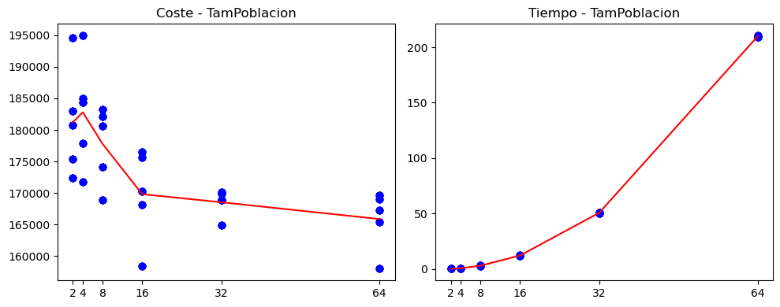

```python
graficar(c0,c1,c2,c3,test)
```

```python
test = [2, 4, 8, 16, 32, 64]
d0 = []
d1 = []
d2 = []
d3 = []
for i in tqdm(test, desc="Elite Cromosomica"):
    per = pruebas("Elite Cromosomica con n=" + str(i), elite_cromosomica, Localizaciones(filename='./data/US120.txt'), i, 500, 0.1, 0.95)
    d0.append(per[0])
    d1.append(per[1])
    d2.append(per[2])
    d3.append(per[3])
```

```
Elite Cromosomica con n=2
```

```
La media de los tiempos es:  0.1573204517364502
La desviacion de los tiempos es:  0.004133695003711728
La media de los resultados es:  182868.55559543634
La desviacion de los resultados es:  5586.850228291883
-------------

Elite Cromosomica con n=4
```

```
La media de los tiempos es:  0.7501641273498535
La desviacion de los tiempos es:  0.016003956752273736
La media de los resultados es:  179905.68541211015
La desviacion de los resultados es:  3448.003127542729
-------------

Elite Cromosomica con n=8
```

```
La media de los tiempos es:  3.477378797531128
La desviacion de los tiempos es:  0.03693878581220625
La media de los resultados es:  176589.40825877996
La desviacion de los resultados es:  3404.3554036156356
-------------

Elite Cromosomica con n=16
```

```
La media de los tiempos es:  15.22093563079834
La desviacion de los tiempos es:  0.04490472005491529
La media de los resultados es:  173167.04173317293
La desviacion de los resultados es:  4665.770900557035
-------------

Elite Cromosomica con n=32
```

```
La media de los tiempos es:  64.51859498023987
La desviacion de los tiempos es:  0.12905571340782968
La media de los resultados es:  171802.66234821375
La desviacion de los resultados es:  5674.733592652545
-------------

Elite Cromosomica con n=64
```

```
La media de los tiempos es:  281.0288592338562
La desviacion de los tiempos es:  12.087548762948273
La media de los resultados es:  168773.56324639716
La desviacion de los resultados es:  3407.8519874640674
-------------
```

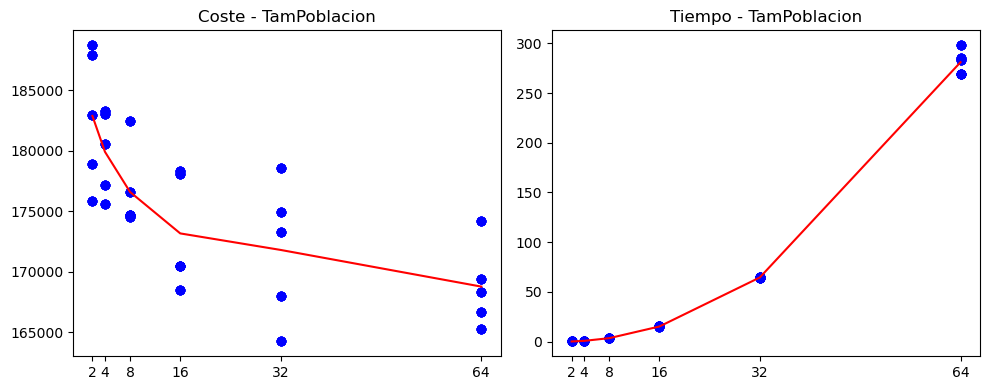

```python
graficar(d0,d1,d2,d3,test)
```

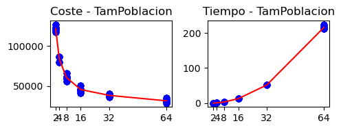

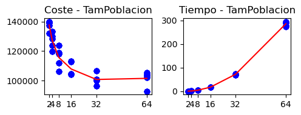

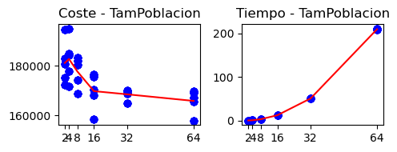

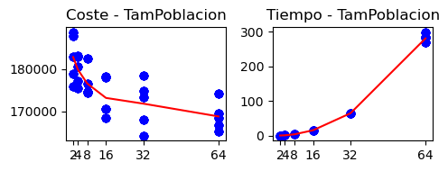

```python
test = [2, 4, 8, 16, 32, 64]
graficar(a0,a1,a2,a3,test)
graficar(b0,b1,b2,b3,test)
graficar(c0,c1,c2,c3,test)
graficar(d0,d1,d2,d3, test)
```

### Analisis de Resultados

En este primer apartado, se va a evaular como afecta el tamaño de las poblaciones al coste de la solución óptima, generada por el algoritmo genético. De esta manera se analizará el tamaño de las poblaciones con respecto al coste y tiempo para cada una de las cuatro variantes que se han generado. Utilizando la función graficar se obtienen las siguientes tablas:

[figure not shown]

En las variantes de Mitades se obtiene una función logaritmica decreciente, donde para valores de n muy pequeños genera soluciones con un coste muy alto y con valores de n altos reduce el coste de dichas soluciones. Sin embargo el coste temporal aumenta muy considerablemente cuanto mayor sea la n. A pesar de que las dos variantes siguen la misma tendencia, la Mitades Individual comienza, incluso en valores de n pequeños, con un coste medio de la solución muy inferior con respecto al que consigue Mitades Cromosómica. Por ejemplo, para n=32 Mitades Individual tiene un coste de la solución óptima medio de 38096.54km , mientras que Mitades Cromosómica tienen un coste medio de 100.756,62km.

Por otro lado, las variantes de Elite siguen una tendencia descreciente, pueden equipararse a una función lineal con una pendiente ligeramente negativa. A pesar de la disminución de coste, cuanto mayor es el tamaño de la población, obtienen como resultado costes de la solución óptima superiores a 160.000km, que es cuatro veces más que la solución aportada por Mitades Individual.

Para escoger un buen tamaño de población, no es suficiente con analiza el coste de las soluciones óptimas, sino también el coste computacional y temporal que tienen dichas soluciones. En este caso, de los tamaños analizados n = 32 es el óptimo ya que se obtiene un resultado no muy diferente a tamaño mayores como n = 64 con una reducción del coste temporal superior al 50% de media.

## Pregunta 3. Probabilidad de mutación

### Parte Experimental

```python
test = [0, 0.1, 0.2, 0.3, 0.4, 0.5, 0.6, 0.7, 0.8, 0.9, 1]
a00 = []
a11 = []
a22 = []
a33 = []
for i in tqdm(test, desc="Mitades Individual"):
    per = pruebas("Mitades Individual con prob=" + str(i), mitades_individual, Localizaciones(filename='./data/US120.txt'), 32, 500, i, 0.95)
    a00.append(per[0])
    a11.append(per[1])
    a22.append(per[2])
    a33.append(per[3])
```

```
Mitades Individual con prob=0
```

```
La media de los tiempos es:  50.19085516929626
La desviacion de los tiempos es:  0.1332387839699136
La media de los resultados es:  75067.4566331433
La desviacion de los resultados es:  13804.626772333255
-------------

Mitades Individual con prob=0.1
```

```
La media de los tiempos es:  51.0632360458374
La desviacion de los tiempos es:  0.17368345359872553
La media de los resultados es:  36727.397305779734
La desviacion de los resultados es:  3492.2100210604813
-------------

Mitades Individual con prob=0.2
```

```
La media de los tiempos es:  51.19510869979858
La desviacion de los tiempos es:  0.18245343273978043
La media de los resultados es:  35103.806343951524
La desviacion de los resultados es:  4337.710543258033
-------------

Mitades Individual con prob=0.3
```

```
La media de los tiempos es:  51.36146273612976
La desviacion de los tiempos es:  0.09866825250568126
La media de los resultados es:  35285.400031066914
La desviacion de los resultados es:  3712.886355051808
-------------

Mitades Individual con prob=0.4
```

```
La media de los tiempos es:  51.651017379760745
La desviacion de los tiempos es:  0.263100167960063
La media de los resultados es:  37849.132969628336
La desviacion de los resultados es:  3345.0221423762923
-------------

Mitades Individual con prob=0.5
```

```
La media de los tiempos es:  51.90888071060181
La desviacion de los tiempos es:  0.22276466160878672
La media de los resultados es:  35334.438096320264
La desviacion de los resultados es:  1891.8620984701147
-------------

Mitades Individual con prob=0.6
```

```
La media de los tiempos es:  52.25578474998474
La desviacion de los tiempos es:  0.08393564536662519
La media de los resultados es:  39448.3851071463
La desviacion de los resultados es:  2091.0240089291774
-------------

Mitades Individual con prob=0.7
```

```
La media de los tiempos es:  52.59677090644836
La desviacion de los tiempos es:  0.14009430757407298
La media de los resultados es:  39538.83256251082
La desviacion de los resultados es:  4278.963018633328
-------------

Mitades Individual con prob=0.8
```

```
La media de los tiempos es:  52.84023718833923
La desviacion de los tiempos es:  0.0792302100129463
La media de los resultados es:  38218.93007548617
La desviacion de los resultados es:  3607.542600358109
-------------

Mitades Individual con prob=0.9
```

```
La media de los tiempos es:  53.58019151687622
La desviacion de los tiempos es:  0.15033630260881853
La media de los resultados es:  40582.6074735005
La desviacion de los resultados es:  2285.837692016812
-------------

Mitades Individual con prob=1
```

```
La media de los tiempos es:  54.74016008377075
La desviacion de los tiempos es:  0.18989562122922785
La media de los resultados es:  40483.04608653139
La desviacion de los resultados es:  6354.030812311823
-------------
```

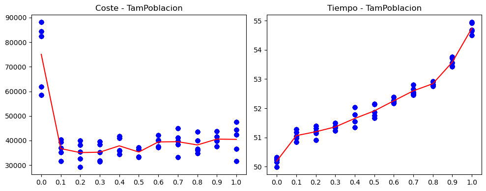

```python
graficar(a00,a11,a22,a33,test)
```

```python
test = [0, 0.1, 0.2, 0.3, 0.4, 0.5, 0.6, 0.7, 0.8, 0.9, 1]
b00 = []
b11 = []
b22 = []
b33 = []
for i in tqdm(test, desc="Mitades Cromosomica"):
    per = pruebas("Mitades Cromosomica con prob=" + str(i), mitades_cromosomica, Localizaciones(filename='./data/US120.txt'), 32, 500, i, 0.95)
    b00.append(per[0])
    b11.append(per[1])
    b22.append(per[2])
    b33.append(per[3])
```

```
Mitades Cromosomica con prob=0
```

```
La media de los tiempos es:  57.8714252948761
La desviacion de los tiempos es:  0.4686509255021333
La media de los resultados es:  72988.82605122286
La desviacion de los resultados es:  8760.815085448912
-------------

Mitades Cromosomica con prob=0.1
```

```
La media de los tiempos es:  67.58376269340515
La desviacion de los tiempos es:  0.5575856251208481
La media de los resultados es:  103437.15349955794
La desviacion de los resultados es:  2960.9962157432396
-------------

Mitades Cromosomica con prob=0.2
```

```
La media de los tiempos es:  70.70296654701232
La desviacion de los tiempos es:  1.1481980970834702
La media de los resultados es:  127802.79985874191
La desviacion de los resultados es:  2244.754883949636
-------------

Mitades Cromosomica con prob=0.3
```

```
La media de los tiempos es:  71.56670732498169
La desviacion de los tiempos es:  0.6819556510576333
La media de los resultados es:  139447.37870519393
La desviacion de los resultados es:  1968.2294702851302
-------------

Mitades Cromosomica con prob=0.4
```

```
La media de los tiempos es:  73.53244581222535
La desviacion de los tiempos es:  0.5825240568583593
La media de los resultados es:  144847.8650524321
La desviacion de los resultados es:  1722.365510429321
-------------

Mitades Cromosomica con prob=0.5
```

```
La media de los tiempos es:  75.06875228881836
La desviacion de los tiempos es:  0.5897078503162668
La media de los resultados es:  144055.91147275284
La desviacion de los resultados es:  2294.810248779908
-------------

Mitades Cromosomica con prob=0.6
```

```
La media de los tiempos es:  76.51184158325195
La desviacion de los tiempos es:  0.179441742963103
La media de los resultados es:  147939.19831570415
La desviacion de los resultados es:  1905.5974466471946
-------------

Mitades Cromosomica con prob=0.7
```

```
La media de los tiempos es:  78.10451831817628
La desviacion de los tiempos es:  0.32715345083036934
La media de los resultados es:  147282.46920270752
La desviacion de los resultados es:  1331.6811238077355
-------------

Mitades Cromosomica con prob=0.8
```

```
La media de los tiempos es:  79.70987529754639
La desviacion de los tiempos es:  0.13936049330074324
La media de los resultados es:  148738.15519899395
La desviacion de los resultados es:  925.3625603842419
-------------

Mitades Cromosomica con prob=0.9
```

```
La media de los tiempos es:  81.46230039596557
La desviacion de los tiempos es:  0.27925028925688355
La media de los resultados es:  147362.568630673
La desviacion de los resultados es:  1242.2013420816513
-------------

Mitades Cromosomica con prob=1
```

```
La media de los tiempos es:  83.98496809005738
La desviacion de los tiempos es:  0.24555672347271257
La media de los resultados es:  147970.4920808504
La desviacion de los resultados es:  3146.43969149794
-------------
```

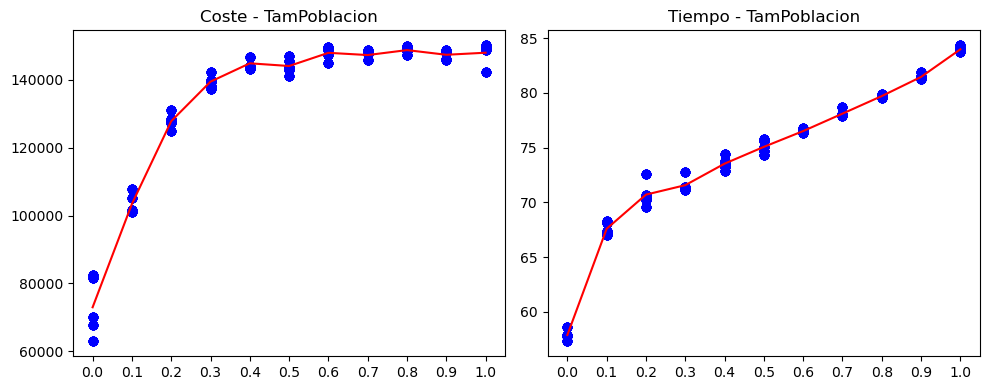

```python
graficar(b00,b11,b22,b33,test)
```

```python
test = [0, 0.1, 0.2, 0.3, 0.4, 0.5, 0.6, 0.7, 0.8, 0.9, 1]
c00 = []
c11 = []
c22 = []
c33 = []
for i in tqdm(test, desc="Elite Individual"):
    per = pruebas("Elite Cromosomica con prob=" + str(i), elite_individual, Localizaciones(filename='./data/US120.txt'), 32, 500, i, 0.95)
    c00.append(per[0])
    c11.append(per[1])
    c22.append(per[2])
    c33.append(per[3])
```

```
Elite Cromosomica con prob=0
```

```
La media de los tiempos es:  49.7786949634552
La desviacion de los tiempos es:  0.08789824118118005
La media de los resultados es:  171505.48293753518
La desviacion de los resultados es:  3747.5585455788196
-------------

Elite Cromosomica con prob=0.1
```

```
La media de los tiempos es:  50.08374881744385
La desviacion de los tiempos es:  0.10210211272810582
La media de los resultados es:  170230.52815480984
La desviacion de los resultados es:  3080.5292189731585
-------------

Elite Cromosomica con prob=0.2
```

```
La media de los tiempos es:  51.10885286331177
La desviacion de los tiempos es:  0.8911660361651669
La media de los resultados es:  174405.43899842817
La desviacion de los resultados es:  2325.5344018264595
-------------

Elite Cromosomica con prob=0.3
```

```
La media de los tiempos es:  51.98477206230164
La desviacion de los tiempos es:  0.16994064365727932
La media de los resultados es:  171596.16423400154
La desviacion de los resultados es:  4521.037732513986
-------------

Elite Cromosomica con prob=0.4
```

```
La media de los tiempos es:  52.094655179977416
La desviacion de los tiempos es:  0.2058543757570901
La media de los resultados es:  171121.45353417267
La desviacion de los resultados es:  3340.196713594399
-------------

Elite Cromosomica con prob=0.5
```

```
La media de los tiempos es:  51.36641836166382
La desviacion de los tiempos es:  0.16800250296726252
La media de los resultados es:  168979.80962547992
La desviacion de los resultados es:  3215.7902387921627
-------------

Elite Cromosomica con prob=0.6
```

```
La media de los tiempos es:  51.58550319671631
La desviacion de los tiempos es:  0.10753899173130915
La media de los resultados es:  168875.31089890352
La desviacion de los resultados es:  4526.08499908589
-------------

Elite Cromosomica con prob=0.7
```

```
La media de los tiempos es:  52.041568756103516
La desviacion de los tiempos es:  0.2784512138406791
La media de los resultados es:  172575.04239527907
La desviacion de los resultados es:  2142.6981502295494
-------------

Elite Cromosomica con prob=0.8
```

```
La media de los tiempos es:  53.24905891418457
La desviacion de los tiempos es:  0.25662252033100696
La media de los resultados es:  172644.67694257878
La desviacion de los resultados es:  2159.978528086106
-------------

Elite Cromosomica con prob=0.9
```

```
La media de los tiempos es:  52.90639152526855
La desviacion de los tiempos es:  0.1250357993222461
La media de los resultados es:  172632.51638129415
La desviacion de los resultados es:  2906.7265728057905
-------------

Elite Cromosomica con prob=1
```

```
La media de los tiempos es:  52.94578046798706
La desviacion de los tiempos es:  0.07501231317209153
La media de los resultados es:  170333.84295296756
La desviacion de los resultados es:  7205.85446367276
-------------
```

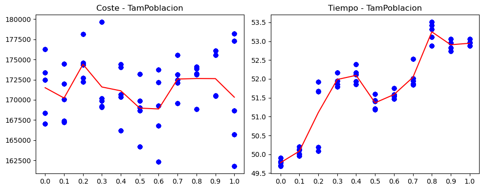

```python
graficar(c00,c11,c22,c33,test)
```

```python
test = [0, 0.1, 0.2, 0.3, 0.4, 0.5, 0.6, 0.7, 0.8, 0.9, 1]
d00 = []
d11 = []
d22 = []
d33 = []
for i in tqdm(test, desc="Elite Cromosomica"):
    per = pruebas("Elite Cromosomica con prob=" + str(i), elite_cromosomica, Localizaciones(filename='./data/US120.txt'), 32, 500, i, 0.95)
    d00.append(per[0])
    d11.append(per[1])
    d22.append(per[2])
    d33.append(per[3])
```

```
Elite Cromosomica con prob=0
```

```
La media de los tiempos es:  58.89276485443115
La desviacion de los tiempos es:  0.21010803216423712
La media de los resultados es:  172102.4671374973
La desviacion de los resultados es:  2844.849812166721
-------------

Elite Cromosomica con prob=0.1
```

```
La media de los tiempos es:  65.70419359207153
La desviacion de los tiempos es:  0.3606810952744733
La media de los resultados es:  172659.52185375764
La desviacion de los resultados es:  1589.244242987451
-------------

Elite Cromosomica con prob=0.2
```

```
La media de los tiempos es:  68.17730450630188
La desviacion de los tiempos es:  0.0542256899243836
La media de los resultados es:  175869.90534529128
La desviacion de los resultados es:  1685.2583614578753
-------------

Elite Cromosomica con prob=0.3
```

```
La media de los tiempos es:  70.20167331695556
La desviacion de los tiempos es:  0.17223600770368858
La media de los resultados es:  173757.12734768848
La desviacion de los resultados es:  2060.3093220755177
-------------

Elite Cromosomica con prob=0.4
```

```
La media de los tiempos es:  72.33776326179505
La desviacion de los tiempos es:  0.14193756038715288
La media de los resultados es:  170282.9772574462
La desviacion de los resultados es:  8667.241941530794
-------------

Elite Cromosomica con prob=0.5
```

```
La media de los tiempos es:  74.14097094535828
La desviacion de los tiempos es:  0.25812995855340715
La media de los resultados es:  169005.0784653816
La desviacion de los resultados es:  6405.891779618853
-------------

Elite Cromosomica con prob=0.6
```

```
La media de los tiempos es:  75.12216410636901
La desviacion de los tiempos es:  0.7541803943599664
La media de los resultados es:  168935.15786883887
La desviacion de los resultados es:  5902.057174667695
-------------

Elite Cromosomica con prob=0.7
```

```
La media de los tiempos es:  76.3698805809021
La desviacion de los tiempos es:  0.37654273133060406
La media de los resultados es:  169381.5851391504
La desviacion de los resultados es:  4600.741106652714
-------------

Elite Cromosomica con prob=0.8
```

```
La media de los tiempos es:  78.43553104400635
La desviacion de los tiempos es:  0.6774900392894184
La media de los resultados es:  172810.00361244165
La desviacion de los resultados es:  3573.224720915912
-------------

Elite Cromosomica con prob=0.9
```

```
La media de los tiempos es:  79.51958565711975
La desviacion de los tiempos es:  0.1738177910035096
La media de los resultados es:  170608.05594090623
La desviacion de los resultados es:  6302.349800320414
-------------

Elite Cromosomica con prob=1
```

```
La media de los tiempos es:  82.50300283432007
La desviacion de los tiempos es:  0.7841289115049662
La media de los resultados es:  170219.05205999475
La desviacion de los resultados es:  5466.46028999347
-------------
```

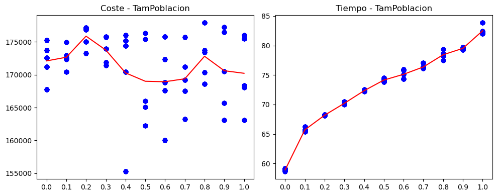

```python
graficar(d00,d11,d22,d33,test)
```

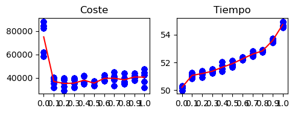

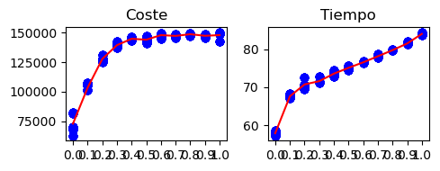

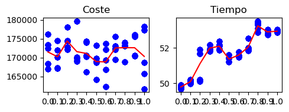

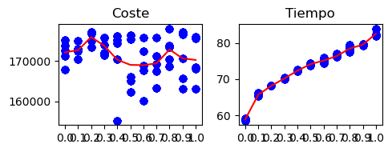

```python
test = [0, 0.1, 0.2, 0.3, 0.4, 0.5, 0.6, 0.7, 0.8, 0.9, 1]
graficar(a00,a11,a22,a33,test)
graficar(b00,b11,b22,b33,test)
graficar(c00,c11,c22,c33,test)
graficar(d00,d11,d22,d33, test)
```

### Analisis de Resultados

Una vez analizado y escogido el tamaño óptimo para la distintas variantes del algoritmo, se procederá a analizar cúal es la mejor frecuencia para generar mutaciones en los hijos. Las mutaciones son cambios en un genoma del cromosoma si se realizan de forma individual, sino son cambios en el cromosoma completo y se les denomina mutaciones cromosómicas. Para este analisis se realizará un procedimiento similar al anterior generando y analizando las siguientes gráficas:

[figure not shown]

Las gráficas de las variantes que utilizan Mitades para la generación de la nueva población, se observa que no realizar mutaciones Individuales tiene un efecto muy negativo y que es la probabilidad de generar mutaciones es indiferente, ya que el coste medio no varía en función de dicha probabailidad, por lo tanto lo importante es hacer mutaciones da igual su probabilidad. Por otro lado, las mutaciones cromosómicas, en la variante de Mitades, son muy perjudiciales. El algoritmo obtiene mejores soluciones cuando la frecuencia con la que se realizan es del 0% o cercana.

Las gráficas que utilizan Elite para la generación de la nueva población, obtienen soluciones muy dispares, lo que deriva en una media que no es muy fiable ya que su desviación típica es muy alta. Además, no se aprecia ningun tipo de mejora en cuanto a la probabilidad de la mutación, tanto para mutacion individual como cromosómica.

Una vez más, las mejores soluciones son proporcionadas por la variantes Mitades Individual con costes cercarnos pero inferiores a los 40.000km. En cuanto a seleccionar una probabilidad óptima, se debe tener en cuanta que en el caso de Mitades Individual solo se ve afectada en cuanto a coste cuando no se realizan mutaciones, sin embargo cuanta mas frecuencia de mutaciones haya, más coste computacional y temporal tienen generar dichas mutaciones. Por lo tanto, se puede tomar como probabilidad óptima entre un 10% y 25%, por su bajo coste computacional y por su similutud en cuanto a coste de la solución óptima con respecto a otras probabilidades.

## Pregunta 4. Número de iteraciones

### Parte Experimental

```python
test = [50,225,400,575,750,925,1100]
a000 = []
a111 = []
a222 = []
a333 = []
for i in tqdm(test, desc="Mitades Individual"):
    per = pruebas("Mitades Individual con it=" + str(i), mitades_individual, Localizaciones(filename='./data/US120.txt'), 32, i, 0.25, 0.95)
    a000.append(per[0])
    a111.append(per[1])
    a222.append(per[2])
    a333.append(per[3])
```

```
Mitades Individual con it=50
```

```
La media de los tiempos es:  5.617346572875976
La desviacion de los tiempos es:  0.13309786321244316
La media de los resultados es:  62981.74482913568
La desviacion de los resultados es:  1972.4638741276717
-------------

Mitades Individual con it=225
```

```
La media de los tiempos es:  24.437516355514525
La desviacion de los tiempos es:  0.5863528491905988
La media de los resultados es:  40022.36111343914
La desviacion de los resultados es:  5731.517345111761
-------------

Mitades Individual con it=400
```

```
La media de los tiempos es:  42.50181941986084
La desviacion de los tiempos es:  0.6604862625279524
La media de los resultados es:  39334.38259135013
La desviacion de los resultados es:  2723.912227472462
-------------

Mitades Individual con it=575
```

```
La media de los tiempos es:  58.79165711402893
La desviacion de los tiempos es:  0.21676548145566948
La media de los resultados es:  34680.7619022346
La desviacion de los resultados es:  1945.4001059040113
-------------

Mitades Individual con it=750
```

```
La media de los tiempos es:  76.48065295219422
La desviacion de los tiempos es:  0.1685305016967879
La media de los resultados es:  34650.043390791434
La desviacion de los resultados es:  3153.8444370128273
-------------

Mitades Individual con it=925
```

```
La media de los tiempos es:  94.51750526428222
La desviacion de los tiempos es:  0.391972116940246
La media de los resultados es:  35457.010824568155
La desviacion de los resultados es:  3186.0906490662437
-------------

Mitades Individual con it=1100
```

```
La media de los tiempos es:  111.73043885231019
La desviacion de los tiempos es:  0.2902058728830595
La media de los resultados es:  35207.438793255395
La desviacion de los resultados es:  2838.3147104585187
-------------
```

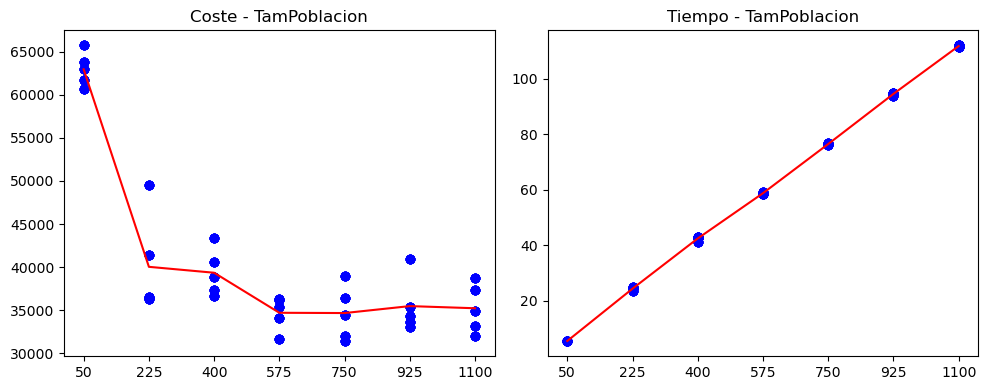

```python
graficar(a000,a111,a222,a333,test)
```

```python
test = [50,225,400,575,750,925,1100]
b000 = []
b111 = []
b222 = []
b333 = []
for i in tqdm(test, desc="Mitades Cromosomica"):
    per = pruebas("Mitades Cromosomica con it=" + str(i), mitades_cromosomica, Localizaciones(filename='./data/US120.txt'), 32, i, 0.1, 0.95)
    b000.append(per[0])
    b111.append(per[1])
    b222.append(per[2])
    b333.append(per[3])
```

```
Mitades Cromosomica con it=50
```

```
La media de los tiempos es:  7.107034301757812
La desviacion de los tiempos es:  0.32349327485207585
La media de los resultados es:  122428.17044512171
La desviacion de los resultados es:  2021.4639556125023
-------------

Mitades Cromosomica con it=225
```

```
La media de los tiempos es:  30.54073476791382
La desviacion de los tiempos es:  0.20739327622121592
La media de los resultados es:  109483.71193897139
La desviacion de los resultados es:  3997.9041868278296
-------------

Mitades Cromosomica con it=400
```

```
La media de los tiempos es:  53.85090885162354
La desviacion de los tiempos es:  0.12228293997254032
La media de los resultados es:  107710.55241401662
La desviacion de los resultados es:  2720.3226114735935
-------------

Mitades Cromosomica con it=575
```

```
La media de los tiempos es:  77.43361678123475
La desviacion de los tiempos es:  0.2164225708156167
La media de los resultados es:  106478.98095401298
La desviacion de los resultados es:  5383.051753854748
-------------

Mitades Cromosomica con it=750
```

```
La media de los tiempos es:  101.24301681518554
La desviacion de los tiempos es:  0.30044733815939195
La media de los resultados es:  104015.04428691804
La desviacion de los resultados es:  1457.1210156364566
-------------

Mitades Cromosomica con it=925
```

```
La media de los tiempos es:  125.03348445892334
La desviacion de los tiempos es:  0.7499853398227125
La media de los resultados es:  100033.34915410103
La desviacion de los resultados es:  4898.924958255648
-------------

Mitades Cromosomica con it=1100
```

```
La media de los tiempos es:  147.80605974197388
La desviacion de los tiempos es:  0.7704458658500049
La media de los resultados es:  98829.85170727376
La desviacion de los resultados es:  4006.738497624008
-------------
```

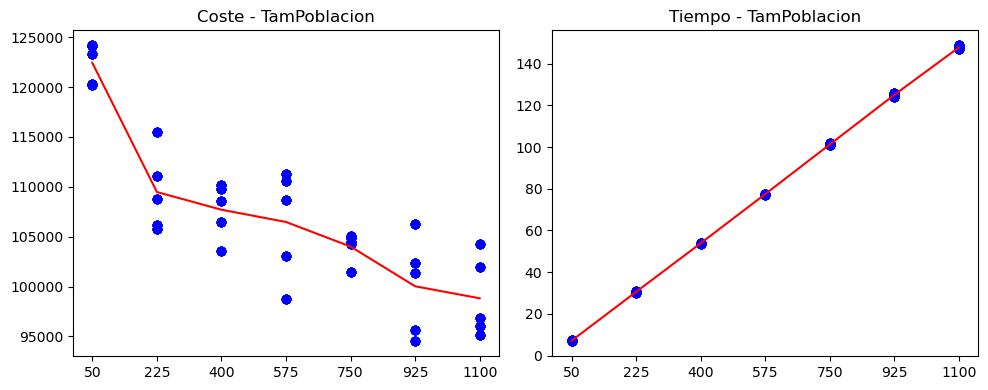

```python
graficar(b000,b111,b222,b333,test)
```

```python
test = [50,225,400,575,750,925,1100]
c000 = []
c111 = []
c222 = []
c333 = []
for i in tqdm(test, desc="Elite Individual"):
    per = pruebas("Elite Cromosomica con it=" + str(i), elite_individual, Localizaciones(filename='./data/US120.txt'), 32, i, 0.25, 0.95)
    c000.append(per[0])
    c111.append(per[1])
    c222.append(per[2])
    c333.append(per[3])
```

```
Elite Cromosomica con it=50
```

```
La media de los tiempos es:  5.326984119415283
La desviacion de los tiempos es:  0.07466725540397125
La media de los resultados es:  172763.20470009427
La desviacion de los resultados es:  4051.2801781590115
-------------

Elite Cromosomica con it=225
```

```
La media de los tiempos es:  22.942139291763304
La desviacion de los tiempos es:  0.0658772673807361
La media de los resultados es:  169803.47014122322
La desviacion de los resultados es:  5275.303290719379
-------------

Elite Cromosomica con it=400
```

```
La media de los tiempos es:  40.45357685089111
La desviacion de los tiempos es:  0.10854846374684451
La media de los resultados es:  172749.68611913826
La desviacion de los resultados es:  4774.7605236808095
-------------

Elite Cromosomica con it=575
```

```
La media de los tiempos es:  58.495473575592044
La desviacion de los tiempos es:  0.1593072829059167
La media de los resultados es:  171759.7949889757
La desviacion de los resultados es:  4835.049399085277
-------------

Elite Cromosomica con it=750
```

```
La media de los tiempos es:  76.2141520023346
La desviacion de los tiempos es:  0.608284090358298
La media de los resultados es:  171544.36483838185
La desviacion de los resultados es:  4435.048295434298
-------------

Elite Cromosomica con it=925
```

```
La media de los tiempos es:  93.2262348651886
La desviacion de los tiempos es:  0.2928588775876427
La media de los resultados es:  170861.35086671976
La desviacion de los resultados es:  3215.1146366618846
-------------

Elite Cromosomica con it=1100
```

```
La media de los tiempos es:  111.12812104225159
La desviacion de los tiempos es:  0.5996308853030555
La media de los resultados es:  169144.8114503
La desviacion de los resultados es:  5267.7557562363745
-------------
```

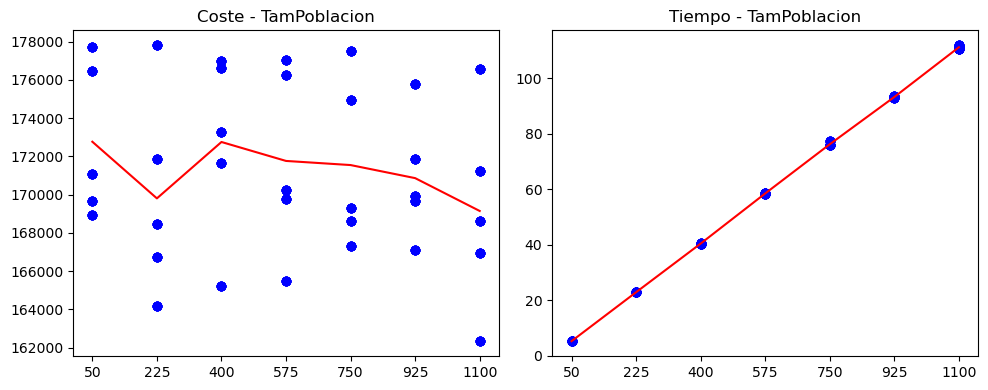

```python
graficar(c000,c111,c222,c333,test)
```

```python
test = [50,225,400,575,750,925,1100]
d000 = []
d111 = []
d222 = []
d333 = []
for i in tqdm(test, desc="Elite Cromosomica"):
    per = pruebas("Elite Cromosomica con it=" + str(i), elite_cromosomica, Localizaciones(filename='./data/US120.txt'), 32, i, 0.1, 0.95)
    d000.append(per[0])
    d111.append(per[1])
    d222.append(per[2])
    d333.append(per[3])
```

```
Elite Cromosomica con it=50
```

```
La media de los tiempos es:  6.526543378829956
La desviacion de los tiempos es:  0.03970093712841162
La media de los resultados es:  170714.5042955605
La desviacion de los resultados es:  4454.845007180615
-------------

Elite Cromosomica con it=225
```

```
La media de los tiempos es:  29.28655161857605
La desviacion de los tiempos es:  0.08150234446638652
La media de los resultados es:  172249.6959483245
La desviacion de los resultados es:  3011.9142623063026
-------------

Elite Cromosomica con it=400
```

```
La media de los tiempos es:  51.71626844406128
La desviacion de los tiempos es:  0.3039815404951004
La media de los resultados es:  170252.33860455986
La desviacion de los resultados es:  2554.4944383337265
-------------

Elite Cromosomica con it=575
```

```
La media de los tiempos es:  74.34250349998474
La desviacion de los tiempos es:  0.49598692493290014
La media de los resultados es:  167721.22199297315
La desviacion de los resultados es:  5282.579841640997
-------------

Elite Cromosomica con it=750
```

```
La media de los tiempos es:  96.54052572250366
La desviacion de los tiempos es:  0.09569890088364905
La media de los resultados es:  173221.10084162405
La desviacion de los resultados es:  1943.7119553074365
-------------

Elite Cromosomica con it=925
```

```
La media de los tiempos es:  119.38861894607544
La desviacion de los tiempos es:  0.5082864483503219
La media de los resultados es:  171629.76576156926
La desviacion de los resultados es:  6372.841150004071
-------------

Elite Cromosomica con it=1100
```

```
La media de los tiempos es:  141.49088983535768
La desviacion de los tiempos es:  0.29620050725267083
La media de los resultados es:  172904.85153582148
La desviacion de los resultados es:  3832.2278050294726
-------------
```

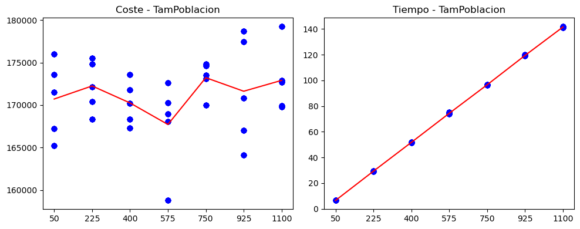

```python
graficar(d000,d111,d222,d333,test)
```

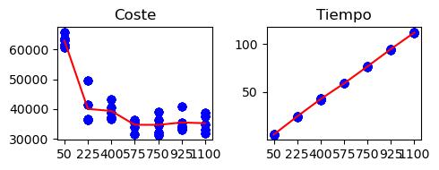

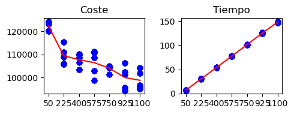

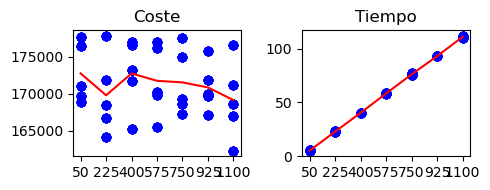

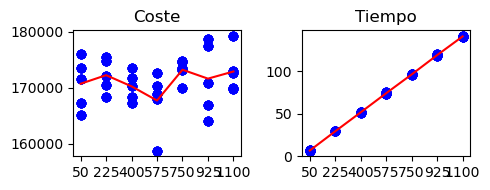

```python
test = [50,225,400,575,750,925,1100]
graficar(a000,a111,a222,a333,test)
graficar(b000,b111,b222,b333,test)
graficar(c000,c111,c222,c333,test)
graficar(d000,d111,d222,d333, test)
```

### Analisis de Resultados

[figure not shown]

En terminos de coste computacional y temporal es evidente que cuantas más iteraciones se quieran ejecutar, mayor será el tiempo que se necesite. En todas las gráficas se puede observar que el número de iteraciones es directamente proporcional al tiempo que se necesita, lo que deriva en una línea recta creciente.

## Conlusiones

A modo de conclusiones, queda claro que la mejor variante, en cuanto a coste de la mejor solución óptima y al coste temporal, de las implementaciones que se han desarrollado sobre el algoritmo genetico es la variante Mitades Individual. Esta variante viene acompañada de tamaño de población, n = 32; con una probabilidad de mutación, prob = [10,25]% y un número de itracciones comprendido entre [500,900] ya que son suficientes para obtener una buena solución en un tiempo muy razobale. Sin embargo, todas estas variantes y pruebas se han desarrollado a través de Agrupación por pares para la selección de los padres, que puede ser que beneficie considerablemente a la variante Mitades Individual. Se podría implementar otra forma de seleccionar a los padres dentro de la población como ruleta o torneo y extraer aún más conclusiones.